# 3.1: Overview of Freight Transport

## 7. Ports and inland infrastructure

**Transloading** is the process of transferring a shipment from one transport vehicle to another, also known as (or similar to) transshipping. Advantages of transloading at a port prior to transport to inland distribution centers (DCs) are the following:

- the contents of four 40-ft containers fit into three 53-ft domestic containers or semi-trailers,
- the empty 40-ft containers do not need to be returned from DC, and
- probably most important, the final assignment to DCs can be delayed since the contents of the incoming container can be re-sorted based on the most up-to-date demand information, instead of shipping the full contents to a single DC.

The major disadvantage of transloading is the increased handling, both in terms of its cost and potential for damage.

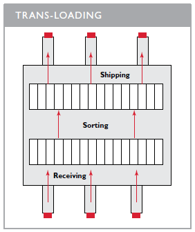

Figure 23: Transloading: receiving on one side, sorting, shipping on the other.[^40]

The reason the box changes size at the port is a mismatch between two standards. The 40-ft container suits the ship, and it suited the American trailer too while the legal maximum was 40 ft. From about the 1990s that maximum rose to 53 ft, and a 40-ft box on a 53-ft truck now gives up thirteen feet of length and everything it could have held.

Hence a third kind of box. A **domestic container** never goes to sea; it moves on land only, and it is built to the size of the tractor-trailer. The large buildings beside a port are transloading facilities, and all they do is take the contents of the 40-ft boxes, sort them, and load them into 53-ft ones for the outbound leg. Fig. 23 is that building in one picture. The first saving is arithmetic: four trucks become three.

An example makes the point concrete. Each outbound truck is going to a different distribution center, and the split is decided after the sort. A cold spell in the Northeast has raised demand for gloves there while Texas is still warm, so most of the gloves go north and fewer go to Texas. The alternative is committing to that split in China a month earlier, against a forecast nobody could make well. So transloading buys two things at the cost of one extra handling: cheaper line-haul, and the right to decide late.

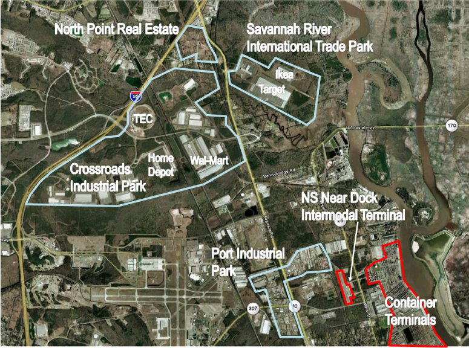

Figure 24: The Savannah logistics cluster: container terminals on the river, and the transloading estates that grew inland from them.[^41]

Fig. 24 is what that looks like from the air. The container terminals sit on the Savannah River, and the large buildings spread inland from them are transloading facilities: Walmart, Home Depot, Target, IKEA. This is what grows around a port that transloads, and it is not something one sees without an aerial photograph.

[figure not shown]

The chain that produced Fig. 25 starts at the canal. Widening it brought more freight into Savannah, that freight has to reach destinations inland and north, and the truck share of I-75’s capacity grew accordingly. The answer proposed is a road for trucks only: two barrier-separated lanes in the I-75 median, reserved for commercial vehicles, running from just south of Atlanta down toward the port. Taking the trucks out of the general-purpose lanes is expected to reduce congestion, reduce truck-and-car accidents, and cut the maintenance those lanes need. It is to open to traffic in 2032 at an estimated $2 billion.[^43] It is the kind of infrastructure worth having more of, and a corridor like I-95 north of Richmond is the obvious candidate.

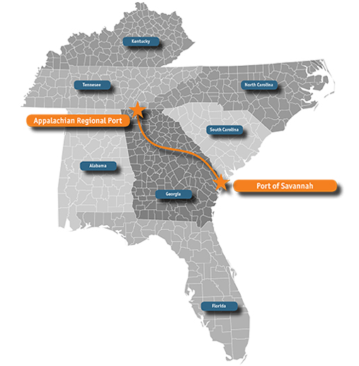

[figure not shown]

Figure 26: The Appalachian Regional Port: 388 miles of rail from Savannah, and the terminal at the far end.[^44]

The last of these is an **inland port**, and Fig. 26 shows what the term means. A direct 388-mile rail route runs from Savannah to the Appalachian Regional Port in north Georgia, bypassing Atlanta’s congestion on the way, and at the far end the facility is treated exactly as an ocean port would be: boxes come off rail and onto trucks there instead of at the coast. From that point the trucks reach all of Kentucky and as far as Chicago. What it buys at the other end is less truck congestion at the port itself, and no need to transload near the coast at all. It opened in August 2018.

What everything in this section has in common is that none of it is reported anywhere a person would come across it. The raised bridges, the trench, the truck lanes and the inland port all have to be looked for. They are large, slow, expensive and almost entirely below the public’s line of sight, which is a good part of why the cost of moving a ton one mile reads like a fact of nature rather than the result of somebody’s capital program.

## 8. Freight terms

Freight transport uses a couple of dozen ordinary English words in particular ways. None of them is a technical term and none needs deriving; what they need is meeting once, because everything after this uses them without stopping to explain.

**Demurrage**: per-day fee charged by the carrier for keeping a container or trailer past the free window written into the contract

The fee exists because a trailer is cheap storage. A warehouse short of space can leave a load in the trailer it arrived in, tell the carrier it has not got round to unloading, and gain outdoor storage for nothing. So the contract sets a window, often twenty-four or forty-eight hours, and after it the carrier charges by the day, possibly hundreds of dollars a day. Nobody comes to take the trailer back; the charge is the whole of the enforcement.

**Drayage**: short-distance transport, typically to or from a port or rail terminal (from the dray horse that once did it)

**Dunnage**: material used to secure cargo inside a container (air bag, “popcorn”)

**Bill of Lading**: contract between carrier and shipper that serves as title for shipment

It is the paperwork the rest of the arrangement hangs on, and it is where the demurrage window and its per-day fee are written down. Much of the document is now moving onto a blockchain, on the same reasoning that moved currency there.

**FOB (Free-on-Board)**: indicates when seller transfers title to buyer, and with it which party pays the freight

Fig. 2 in Lecture 2.2 is the four cases, seller or buyer against inbound or outbound. Lecture 2.2 works out why the choice fixes who pays for the freight without usually moving a location decision.

**Reefer**: refrigerated container or trailer

**Common Carrier (vs Private Carrier)**: carrier that serves general public, as against one that carries only its owner’s goods

**3PL (third-party logistics provider)**: firm that specializes in providing warehousing and transportation services for hire

**Truck (vs. Tractor-Trailer)**: vehicle carrying its load on the same chassis as the cab, where a tractor-trailer is a separate power unit pulling a detachable trailer (Fig. 27)

**Bobtail**: tractor running with no trailer attached (Fig. 27)

[figure not shown]

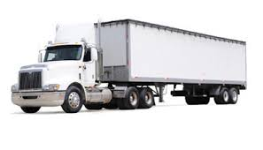

[figure not shown]

Figure 27: A truck, a tractor-trailer, and a tractor running bobtail.[^45]

**Deadheading**: truck travel without a load

It is invisible from outside, because the trailer is still there whether it is full or not. The one clue from a car is acceleration: a truck pulling away from a light faster than the traffic around it is almost certainly empty. A great deal of truck travel is deadhead, and those are unproductive miles, so minimizing them is close to the objective function of running a carrier.

**Doubles**: one tractor pulling two trailers coupled in line (Fig. 28)

**Fifth Wheel (and Kingpin)**: coupling plate mounted over the tractor’s rear axles, into which the kingpin under the front of a trailer drops and locks (Fig. 28)

[figure not shown]

[figure not shown]

Figure 28: Doubles, and the fifth wheel a trailer’s kingpin drops into.[^46]

**Hours-of-Service (HOS) regulations**: federal limits on a driver’s time at the wheel, allowing up to 11 hours of driving within a 14-hour on-duty window, which begins after 10 or more consecutive hours off duty

**Sleeper, Driver Team**: allows non-stop travel with one person driving while other sleeps

This is what the hours-of-service rule leaves open: two drivers, one at the wheel and one asleep, and the truck never stops. A driver who worked such a team described running Lakeland to Los Angeles with a single refueling stop in Texas, three weeks at a time, door to door in something over thirty hours. That is *faster than air cargo* for the same lane, because the air route adds a drive to the airport, a wait for a plane, the flight, unloading, and the delivery at the far end. Table 1 gives the cost of a ton-mile; it does not say which mode arrives first.

**Tare Weight**: Tare = Gross vehicle weight – Payload

**Lumper**: laborer hired by a trucker to unload freight at a warehouse

The trade exists because of an assumption that turns out to be wrong. It is natural to suppose that a warehouse unloads the trucks arriving at it, with its own people. Unloading is in fact the trucker’s job, and a driver is often in no position to do it, so an outsourced trade of casual labor has grown up around the dock, hired by the trucker rather than by the warehouse. It is the kind of thing that is invisible from a manager’s office and obvious at the dock.

## Endnotes

[^1]: The air industry encodes this threshold explicitly. IATA’s volumetric divisor fixes the density at which a shipment stops being billed on the space it occupies and starts being billed on what it weighs; see Maersk, *Air Cargo Chargeable Weight*, 10 March 2025, https://www.maersk.com/logistics-explained/transportation-and-freight/2025/03/10/air-cargo-chargeable-weight, and DHL Global Forwarding, *Calculating Chargeable Weights*, https://www.dhl.com/us-en/home/global-forwarding/freight-forwarding-education-center/calculating-chargeable-weights.html. Lecture 3.2 gives the figure and sets it beside the trailer and the container.
[^2]: M. G. Kay, *Challenges and Opportunities Associated with Using Autonomous Vehicles and Drones for Home Delivery*, 2020, unpublished. Some of the numbers here are revised from the ones in the report; the analysis behind them is unchanged.
[^3]: The air figure is not from the 2020 report, whose dirt-to-dirt framework does not extend to air cargo. It is the 2018 average freight revenue per ton-mile for domestic scheduled air carrier service, from U.S. Department of Transportation, Bureau of Transportation Statistics, *National Transportation Statistics*, “Table 3-21: Average Freight Revenue Per Ton-mile,” accessed 21 September 2026; the same source and year give 4.23 cents for Class I rail. Cargo revenue there covers scheduled and charter property revenue and mail revenue, and excludes carriers that did not report both financial data and a full year of traffic data, so the figure is a U.S. domestic average set against an international ocean rate. The relative column is that cost divided by the cost of water.
[^4]: M. G. Kay, *Challenges and Opportunities Associated with Using Autonomous Vehicles and Drones for Home Delivery*, 2020, unpublished. As with Table 1, some of the numbers in the figure are revised from the ones in the report; the analysis behind them is unchanged.
[^5]: John Schulz, “State of Logistics 2022: Out of sync,” *Logistics Management*, 2022 https://www.logisticsmgmt.com/article/state_of_logistics_out_of_sync.
[^6]: Schulz, J.D., “State of Logistics 2010: Business logistics costs fall 18.2 percent,” *Modern Material Handling*, Jun. 9, 2010.
[^7]: Trunick, P.A., 2005, “Can we hold the line on logistics costs?” *Logistics TODAY*, Penton Media.
[^8]: John Schulz, “State of Logistics 2022: Out of sync,” *Logistics Management*, 2022 https://www.logisticsmgmt.com/article/state_of_logistics_out_of_sync.
[^9]: Logistics Costs and U.S. Gross Domestic Product, Federal Highway Administration, U.S. Dept. of Transportation, Aug. 25, 2005, http://ops.fhwa.dot.gov/Freight/freight_analysis/econ_methods/lcdp_rep/index.htm.
[^10]: CSCMP’s 33rd Annual State of Logistics Report, as reported in John Schulz, “State of Logistics 2022: Out of sync,” *Logistics Management*, 2022 https://www.logisticsmgmt.com/article/state_of_logistics_out_of_sync.
[^11]: Private inventories: Annual average, seasonally adjusted, Federal Reserve Bank of St. Louis, Series ID A371RC1Q027SBEA. https://fred.stlouisfed.org/series/A371RC1Q027SBEA#0 (accessed 2022.09.26).
[^12]: Record low.
[^13]: 2024 from CSCMP’s 36th Annual State of Logistics Report (released 3 June 2025), which put U.S. business logistics costs at $2.58 trillion; 2025 from the 37th (June 2026), which put them at $2.40 trillion and gave the split as 61.8% transportation, 30.4% inventory carrying and 7.8% other. Each row records the year **as first published**. CSCMP revises the whole series with each report, so the current basis differs: the 37th restates 2022 at 10.2%, 2023 at 8.4% and 2024 at 8.3%, against the 9.04%, 8.76% and 8.8% shown here. The difference is a change of basis, not an error in either figure.
[^14]: *Global Logistics Costs and Third-Party Logistics Revenues for Key Regions and Countries*, Armstrong & Associates, Inc., with International Monetary Fund GDP data; 2025 figures, updated 20 April 2026, accessed 18 September 2026. The basis is not Table 3’s: A&A put U.S. logistics costs at $2,545 billion for 2025 where CSCMP’s 37th report gives $2.40 trillion, which is 8.3% against 7.8% of GDP for the same year. The chart is built to compare **across countries**, which is what this section uses it for, and is not comparable with the tally above.
[^15]: Rail is the mode whose rates can be compared across countries on one basis. CPCS, *International Comparison of Railway Freight Rates*, prepared for the Railway Association of Canada, 31 January 2023, Fig. 4, gives 2021 freight revenue per revenue ton-mile in purchasing-power-adjusted U.S. cents: United States 4.66, against Spain 7.26, Italy 8.12, France 8.13, Germany 9.73 and Japan 12.19. Of the ten countries surveyed, three are lower still: Canada at 4.16, China at 3.51 and Russia at 3.26.
[^16]: F. M. B. A. Furtado, “U.S. and European Freight Railways: The Differences That Matter,” *Journal of the Transportation Research Forum* 52(2), Summer 2013, pp. 65–84. Its 2009 figures put U.S. road and rail together at 2.90 trillion ton-miles, which is 4.24 trillion tonne-km, against 2.05 trillion tonne-km for the EU27. Per head that is 13,817 tonne-km against 4,109, a factor of 3.4.
[^17]: http://fineartamerica.com/featured/knight-riding-horse-sword-cartoon-aloysius-patrimonio.html.
[^18]: *Freight team*, ca. 1905. Library of Congress, Prints and Photographs Division, https://www.loc.gov/item/2013647269/. No known restrictions on publication.
[^19]: https://www.quora.com/What-are-some-rare-photos-of-world-history/answer/Ryan-Bales-5.
[^20]: PBS, *They Made America*, http://www.pbs.org/wgbh/theymadeamerica/whomade/mclean_hi.html.
[^21]: Taggart, S., 1999, “The 20-Ton Packet,” *Wired*, Oct.
[^22]: Container photograph, Wikimedia Commons, http://en.wikipedia.org/wiki/File:Container_01_KMJ.jpg; identification system, Jean-Paul Rodrigue, *The Geography of Transport Systems*, http://people.hofstra.edu/geotrans/eng/ch3en/conc3en/container_identification_system.html.
[^23]: Freightos Baltic Index (FBX), https://fbx.freightos.com/freight-index/FBX.
[^24]: The first two readings are his own. The third is the FBX global index as reported on 7 September 2026 by IndexBox, *Weekly Container Shipping Rates*, which quotes the index’s latest weekly update at $3,520; it is a trade report quoting the index rather than a reading taken from the index directly, the index’s own chart being available only behind a sign-up.
[^25]: Wikipedia, *Twistlock*, http://en.wikipedia.org/wiki/Twistlock.
[^26]: *Twistlocks explained*, mdiddams, https://www.youtube.com/watch?v=wXXnEzXAip4. Linked rather than embedded: this project renders every lecture with `embed-resources: true`, which inlines an iframe’s source as a scriptless snapshot, so an embedded player shows a black frame and does nothing.
[^27]: Economist, 2004, “Boxed in and clogged up,” *Economist*, Oct. 14.
[^28]: Cycle diagram, Smithsonian, *America on the Move*, http://americanhistory.si.edu/onthemove/collection/image_826.html; CenterPoint aerial, http://www.flickr.com/photos/49394874@N08/5125215424/.
[^29]: Jean-Paul Rodrigue, *The Geography of Transport Systems*, after Drewry Shipping Consultants. Rates are for full container loads and include the base ocean shipping rate, port charges at both origin and destination, fuel surcharges and all other surcharges. The site moved from `people.hofstra.edu/geotrans`; the figures are those of 2010.
[^30]: Gregory Arnold, *Global Supply Chain Trends and the Impact on North American Distribution Markets*, Prologis, presented to the U.S. Department of Transportation Federal Highway Administration, 15 July 2009.
[^31]: The 2016 locks are 1,400 ft long by 180 ft wide, but Nimitz- and Ford-class carriers are blocked by the width of their sponsons; see Center for Maritime Strategy, “Can the Greatest Maritime Infrastructure Project Ever Provide Even More Benefits to the United States?” (February 2025). In March 2026, USS Nimitz transferred from Bremerton to Norfolk via a 12,400-nautical-mile route around South America rather than through the canal.
[^32]: *The 2015 Expansion of the Panama Canal and the Impacts on the North American Container Fleet*, John Vickerman, 2013. The third set of locks opened on 26 June 2016, after the presentation the figure comes from was given, which is why it is drawn as a forthcoming change.
[^33]: NAIOP Research Foundation, *The New Age of Trade: The Americas*. The foundation’s copy at `naiop.org/foundation/newageoftrade.pdf` no longer resolves, checked 18 September 2026.
[^34]: Jean-Paul Rodrigue, *The Geography of Transport Systems*: *Piggyback (TOFC) and Doublestack (COFC) Train Cars*, https://transportgeography.org/contents/chapter5/intermodal-transportation-containerization/container-tofc-cofc/, and *40-Foot Containers Doublestacked on a Rail Car*, https://transportgeography.org/contents/chapter5/rail-transportation-pipelines/doublestack-railcar/. The site moved from `people.hofstra.edu/geotrans`, and these are the current locations of the same two figures, checked 18 September 2026.
[^35]: Jean-Paul Rodrigue, *The Geography of Transport Systems*, *Major North American Rail Corridors Improved since 2000*, https://transportgeography.org/contents/chapter5/rail-transportation-pipelines/rail-corridors-north-america-improvement/. The site moved from `people.hofstra.edu/geotrans`, and this is the current location of the same map, checked 18 September 2026.
[^36]: Alameda Corridor Transportation Authority, https://www.acta.org/about/who-we-are/.
[^37]: Radu Săgeată, *Rhine–Main–Danube transcontinental axis*, 2012, as credited on the map itself; reproduced at https://www.researchgate.net/figure/Rhine-Main-Danube-transcontinental-axis-1-Navigable-rivers-2-Navigable-canals-A_fig1_278023765. See also *Rhine–Main–Danube Canal*, Wikipedia, https://en.wikipedia.org/wiki/Rhine%E2%80%93Main%E2%80%93Danube_Canal. The map’s numbered legend is not expanded on the figure; what the passage uses is the continuous navigable line from Rotterdam to the Black Sea.
[^38]: Image and history: http://vanderheide.ca/blog/wp-content/uploads/2017/09/063.jpg and Ernie Smith, *The Railroad Barcode That Came Before the UPC*, Tedium, 5 September 2017, https://tedium.co/2017/09/05/kartrak-railroad-barcode-history/.
[^39]: Tag and reader photographs, Wikimedia Commons, http://en.wikipedia.org/wiki/File:AEItag.jpg and http://en.wikipedia.org/wiki/File:AEIreader.jpg; reader map from Railinc’s IRFi user guide, https://www.railinc.com/irfidoc/help/IRFiUserGuide.pdf.
[^40]: NAIOP Research Foundation, *The New Age of Trade: The Americas*. The foundation’s copy at `naiop.org/foundation/newageoftrade.pdf` no longer resolves, checked 18 September 2026.
[^41]: Jean-Paul Rodrigue, *The Port of Savannah Logistics Cluster*, https://transportgeography.org/?page_id=8490. The site moved from `people.hofstra.edu/geotrans`, and this is the current location of the same study, checked 18 September 2026.
[^42]: Georgia Department of Transportation, *I-75 Commercial Vehicle Lanes*, project fact sheet, https://www.dot.ga.gov/systems/ProjectDocuments/0014203/I-75%20CV%20Lanes%20Fact%20Sheet.pdf. The address previously published for this document no longer resolves; this is the department’s current fact sheet for the same project.
[^43]: Status checked 18 September 2026. The project is in design and environmental review, with construction expected to begin in 2027 and finish about 2032, at roughly $2 billion for 41 miles of barrier-separated lanes through Henry, Spalding, Butts, Lamar and Monroe counties. The slide’s 2029 opening and $1.8 billion estimate were current when it was made.
[^44]: Georgia Ports Authority, *Appalachian Regional Port*, https://gaports.com/facilities/inland-ports/appalachian-regional-port/, accessed 18 September 2026. CSX’s *New Georgia Inland Terminal Planned* news release, and its Appalachian Region Port map and terminal image at `industrialdevelopment.csx.com`, no longer resolve, checked 18 September 2026.
[^45]: The straight truck from Ryder’s reservation vehicle images, `reservations.ryder.com`, and the tractor-trailer from Manheim’s vehicle images, `manheim.com.au`.
[^46]: Doubles, Wikimedia Commons, https://commons.wikimedia.org/wiki/File:40_foot_container_turnpike_double.jpg; fifth wheel, heavycherry.com.